# Project2: Survival data part 2

## 1.2 Parametric Survival Models

### Fit parametric survival models containing treatment (tx) and CD4 count (cd4) as explantory variables.

Fitting the 3 models:

Exponential: $logT = \mathbf{x}^T\mathbf{b} + \epsilon^*$, $exp(\epsilon^*) \sim Exp(\lambda = 1)$

Weibull: $logT = \mathbf{x}^T\mathbf{b} + \sigma \epsilon^*$, $exp(\sigma \epsilon^*) \sim Weibull(\lambda = 1, k =\frac{1}{\lambda})$

Log logistic: $logT = \mathbf{x}^T\mathbf{b} + \sigma \epsilon^*$, $\epsilon^* \sim Logistic(\mu = 0, \sigma = 1)$

```r
mod_exp <- survreg(Surv(time, event == 1) ~ tx + cd4, data = act_data,
                 dist = "exponential")
mod_weibull <- survreg(Surv(time, event == 1) ~ tx + cd4, data = act_data,
                 dist = "weibull")
mod_loglogistic <- survreg(Surv(time, event == 1) ~ tx + cd4, data = act_data,
                 dist = "loglogistic")
summary(mod_exp)
```

```
##
## Call:
## survreg(formula = Surv(time, event == 1) ~ tx + cd4, data = act_data,
##     dist = "exponential")
##               Value Std. Error    z       p
## (Intercept) 6.71473    0.15647 42.9 < 2e-16
## tx          0.66680    0.21489  3.1  0.0019
## cd4         0.01609    0.00251  6.4 1.5e-10
##
## Scale fixed at 1
##
## Exponential distribution
## Loglik(model)= -819.9   Loglik(intercept only)= -856.6
##  Chisq= 73.36 on 2 degrees of freedom, p= 1.2e-16
## Number of Newton-Raphson Iterations: 7
## n= 1151
```

```r
summary(mod_weibull)
```

```
##
## Call:
## survreg(formula = Surv(time, event == 1) ~ tx + cd4, data = act_data,
##     dist = "weibull")
##               Value Std. Error     z       p
## (Intercept) 7.05743    0.25235 27.97 < 2e-16
## tx          0.84013    0.28582  2.94  0.0033
## cd4         0.02063    0.00379  5.44 5.3e-08
## Log(scale)  0.24834    0.09715  2.56  0.0106
##
## Scale= 1.28
##
## Weibull distribution
## Loglik(model)= -816.3   Loglik(intercept only)= -852.9
##  Chisq= 73.2 on 2 degrees of freedom, p= 1.3e-16
## Number of Newton-Raphson Iterations: 9
## n= 1151
```

```r
summary(mod_loglogistic)
```

```
##
## Call:
## survreg(formula = Surv(time, event == 1) ~ tx + cd4, data = act_data,
##     dist = "loglogistic")
##               Value Std. Error     z       p
## (Intercept) 6.82584    0.25453 26.82 < 2e-16
## tx          0.84295    0.28980  2.91  0.0036
## cd4         0.02080    0.00375  5.55 2.9e-08
## Log(scale)  0.20259    0.09558  2.12  0.0340
##
## Scale= 1.22
##
## Log logistic distribution
## Loglik(model)= -815.8   Loglik(intercept only)= -852.7
##  Chisq= 73.73 on 2 degrees of freedom, p= 9.8e-17
## Number of Newton-Raphson Iterations: 6
## n= 1151
```

Comparing the 3 models using AIC

```r
cat("Expontential:",AIC(mod_exp), "Weibull:",AIC(mod_weibull), "Log Logistic:",AIC(mod_loglogistic))
```

```
## Expontential: 1645.838 Weibull: 1640.671 Log Logistic: 1639.655
```

The lowest AIC is for the log logistic model. This is one with the best fit.

Showing a table of estimates of the log logistic model and their 95 % confidence intervals

```r
est = summary(mod_loglogistic)$table[,1]
std = summary(mod_loglogistic)$table[,2]
# Confidence intervals
(CI1 = est[1] + c(-1,1) * qnorm(0.975) * std[1])
```

```
## [1] 6.326973 7.324707
```

```r
(CI2 = est[2] + c(-1,1) * qnorm(0.975) * std[2])
```

```
## [1] 0.2749461 1.4109522
```

```r
(CI3 = est[3] + c(-1,1) * qnorm(0.975) * std[3])
```

```
## [1] 0.01344965 0.02815334
```

```r
(CI4 = est[4] + c(-1,1) * qnorm(0.975) * std[4])
```

```
## [1] 0.01525963 0.38991565
```

```r
# Table of estimates and confidence intervals
cbind(est,matrix(c(CI1, CI2, CI3, CI4), nrow = 4  , byrow = T )) %>% data.frame() %>% plyr::rename(., c("est" = "Estimates", "V2" = "Lower","V3" = "Upper"))
```

```
##              Estimates      Lower      Upper
## (Intercept) 6.82584032 6.32697339 7.32470724
## tx          0.84294916 0.27494613 1.41095220
## cd4         0.02080149 0.01344965 0.02815334
## Log(scale)  0.20258764 0.01525963 0.38991565
```

```r
act_data
```

[output not shown]

```r
coef4 = coef(summary(mod_loglogistic))
mod_loglogistic$scale
```

```
## [1] 1.224567
```

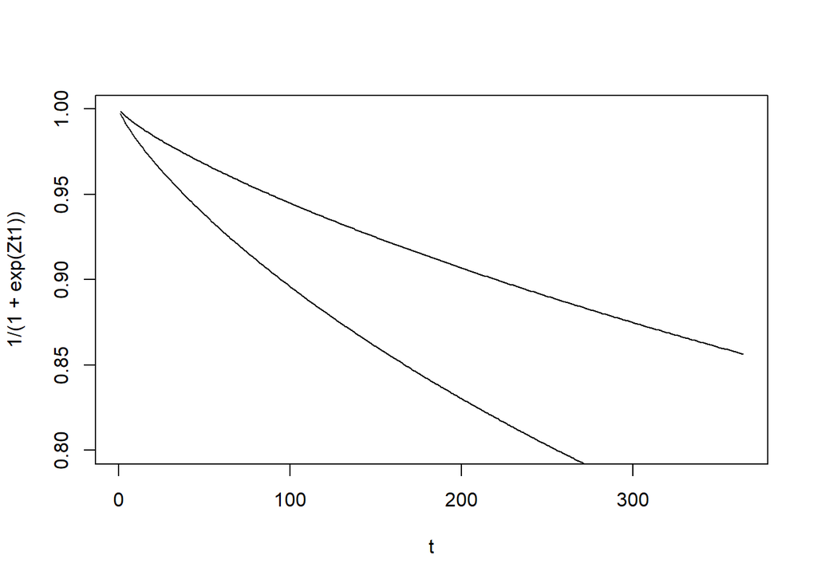

```r
t = sort(act_data$time)
cd4 = 20
Zt1 <- (log(t)-(coef4[1]+coef4[2]+coef4[3]*cd4))/mod_loglogistic$scale
Zt0 <- (log(t)-(coef4[1]+coef4[3]*cd4))/mod_loglogistic$scale
plot(t,1/(1+exp(Zt1)), type = 'l', ylim = c(0.8, 1))
lines(t, 1/(1+exp(Zt0)), type = 'l')
```